# A meta‐analysis of crop pest and natural enemy response to landscape complexity - Chaplin‐Kramer - 2011 - Ecology Letters - Wiley Online Library

[Ecology Letters](https://onlinelibrary.wiley.com/journal/14610248)

[Volume 14, Issue 9](https://onlinelibrary.wiley.com/toc/14610248/2011/14/9) p. 922-932

[figure not shown]

REVIEW AND SYNTHESIS

Full Access

# A meta-analysis of crop pest and natural enemy response to landscape complexity

[Rebecca Chaplin-Kramer](https://onlinelibrary.wiley.com/action/doSearch?ContribAuthorRaw=Chaplin-Kramer%2C+Rebecca),

California Institute for Energy & Environment, University of California, Berkeley, 2087 Addison Street – 2nd Floor, Berkeley, CA 94720, USA.

[Megan E. O’Rourke](https://onlinelibrary.wiley.com/action/doSearch?ContribAuthorRaw=O%27Rourke%2C+Megan+E),

[Eleanor J. Blitzer](https://onlinelibrary.wiley.com/action/doSearch?ContribAuthorRaw=Blitzer%2C+Eleanor+J),

[Claire Kremen](https://onlinelibrary.wiley.com/action/doSearch?ContribAuthorRaw=Kremen%2C+Claire),

First published: 27 June 2011

https://doi.org/10.1111/j.1461-0248.2011.01642.x

Citations: 601

## Abstract

*Ecology Letters* (2011) **14**: 922–932

### Abstract

Many studies in recent years have investigated the relationship between landscape complexity and pests, natural enemies and/or pest control. However, no quantitative synthesis of this literature beyond simple vote-count methods yet exists. We conducted a meta-analysis of 46 landscape-level studies, and found that natural enemies have a strong positive response to landscape complexity. Generalist enemies show consistent positive responses to landscape complexity across all scales measured, while specialist enemies respond more strongly to landscape complexity at smaller scales. Generalist enemy response to natural habitat also tends to occur at larger spatial scales than for specialist enemies, suggesting that land management strategies to enhance natural pest control should differ depending on whether the dominant enemies are generalists or specialists. The positive response of natural enemies does not necessarily translate into pest control, since pest abundances show no significant response to landscape complexity. Very few landscape-scale studies have estimated enemy impact on pest populations, however, limiting our understanding of the effects of landscape on pest control. We suggest focusing future research efforts on measuring population dynamics rather than static counts to better characterise the relationship between landscape complexity and pest control services from natural enemies.

## Introduction

Pest control by chemical means is neither economically nor ecologically sustainable. The United States spent an estimated $11 billion on pesticides in 2008, applying more than 480 million pounds of these chemicals to its agricultural acreage (Fernandez-Cornejo *et al.* 2009). Despite this widespread use of pesticides, which pose myriad threats to humans and wildlife, estimates suggest that 37% of US crop yields are lost to pests (Pimentel *et al.* 1992). The natural enemies of agricultural pests may offer a sustainable solution to pest problems, and the control they provide is valued at $13 billion per year in the United States (Losey & Vaughan 2006). While natural enemies are more diverse and abundant in complex landscapes containing larger amounts of natural habitat, a concomitant improvement in pest control in such landscapes is not well established (Bianchi *et al.* 2006; Kremen & Chaplin-Kramer 2007). Management of ecosystem services like pest control could be greatly enhanced if we better understood the mechanisms contributing to their delivery (Kremen 2005; Luck *et al.* 2009). This study performs a meta-analytic synthesis of the existing literature to ask new questions about the relationships among landscape complexity, scale, natural enemies and crop pests.

The effects of landscape complexity on natural enemies and pests have been explored across a range of cropping systems and study regions, but how ‘landscape complexity’ is defined varies widely from study to study. Most commonly, landscape complexity refers to either the amount of natural or non-crop habitat in the landscape surrounding the farm (e.g. Thies & Tscharntke 1999), or the diversity or heterogeneity of habitats around the farm (e.g. Östman *et al.* 2001), but may also refer to any feature characterising the agricultural landscape (including descriptive non-quantified representations of study regions, e.g. Marino & Landis 1996; Menalled *et al.* 1999, 2003).

Increasing landscape complexity is generally associated with increases in natural enemy abundance and/or diversity (Bianchi *et al.* 2006; Drapela *et al.* 2008; Schmidt *et al.* 2008; Werling & Gratton 2008; Gardiner *et al.* 2009a,b). These increases in enemy abundance and diversity are thought to enhance pest control, and positive relationships between landscape complexity and rates of parasitism or predation have indeed been documented in many systems (Bianchi *et al.* 2006, 2008; Thies *et al.* 2008; Boccaccio & Petacchi 2009; Gardiner *et al.* 2009a). The reduction of pest populations is not given, however. Parasitism rates are positively correlated with pest densities in some systems (Costamagna *et al.* 2004; Thies *et al.* 2005), suggesting that pest densities may sometimes drive parasitoid activity rather than *vice versa*. Furthermore, increased parasitism or predation can be offset by greater pest colonisation in complex landscapes, resulting in no net change in pest populations over a landscape gradient (Roschewitz *et al.* 2005; Thies *et al.* 2005). For these reasons, natural enemy abundance and diversity or parasitism and predation rates alone are not adequate measures of pest control.

A better measure of pest control captures the effects of landscape complexity on the pest populations themselves. The literature on pest responses to landscape complexity, however, is much less conclusive than for natural enemies (Bianchi *et al.* 2006). Studies investigating effects on multiple species frequently found positive relationships with landscape complexity for some species and negative or neutral relationships for others in the same system (e.g. Jonsen & Fahrig 1997; Letourneau & Goldstein 2001). Only a few studies have directly measured effects on the crop as well, and these reveal that increased parasitism in more complex landscapes reduces plant damage by pests, leading to increased yield (Thies & Tscharntke 1999; Thies *et al.* 2003). However, even such well-established examples of pest decline with landscape complexity are challenged by studies documenting the opposite effect in the same system (Zaller *et al.* 2008).

A quantitative synthesis of the existing literature on both natural enemy and pest responses is essential to better understand the landscape ecology of pest control and to provide a rigorous examination of variable results. Previous quantitative syntheses on natural enemies and pests were either conducted at the field rather than landscape scale (field management, Letourneau & Bothwell 2008; Attwood *et al.* 2008; field-scale vegetative diversity, Letourneau *et al.* 2011), or utilised vote count rather than meta-analytic methods (Bianchi *et al.* 2006). At the field-scale, meta-analysis has shown that vegetative diversity enhances natural pest control (Letourneau *et al.* 2011), whereas complexity at the landscape scale had equivocal effects on natural pest control in a vote-count analysis (Bianchi *et al.* 2006). However, vote-count is a weaker tool than meta-analysis for detecting effects (Letourneau *et al.* 2011). Therefore, we use meta-analysis to examine the effects of landscape-scale complexity on crop pests and their natural enemies, and to explore previously unasked questions. The fundamental question we investigate herein is how the responses of these two trophic groups to landscape complexity differ. Since studies vary enormously in the choice of response variables and the definition of landscape complexity, we next ask how methodological differences among studies affect conclusions about the relationship between landscape complexity and pest control. Finally, we utilise this rich data set to ask how specialisation affects natural enemy or pest responses to landscape, and how the scale of these responses may differ. Specifically, we investigate five quantitative questions:

- 1

  How are natural enemies and pests each affected by landscape complexity?
- 2

  How does the measurement of arthropod response (i.e. abundance, diversity, predation, pest control, plant damage) influence conclusions about the impact of landscape complexity?
- 3

  How does the measurement of landscape complexity affect conclusions about its impact?
- 4

  Do specialist and generalist enemies and pests respond differently to landscape complexity?
- 5

  Do enemies and pests or specialists and generalists respond to different spatial scales of landscape complexity?

## Materials and methods

### Study selection

Studies were identified through a comprehensive search on Web of Science last updated in April 2011, using the search string: ‘landscape AND [agr* OR crop] AND [enem* OR predat* OR parasit* OR pest OR biological control]’. Many studies have investigated the effects of vegetative diversity or complexity at local scales (synthesised by Letourneau *et al.* 2011); our goal here was to synthesise the results from studies concerned with complexity at a landscape scale, which we define as ≥ 500 m to include land-cover types extending beyond the field edge. Over 900 abstracts were reviewed for relevance, and 46 studies were ultimately selected using the following criteria: (1) a sample size consisting of at least five unique ‘landscapes,’ in which a landscape comprises a field and the area surrounding it, separated by a minimum distance of 1 km from any other field in the study, (2) quantitative measurements of landscape complexity (as defined below) using GIS or other spatial techniques at ≥ 500 m around the farm, and (3) statistics reported as the univariate relationship between landscape complexity and arthropod response or the partial contribution of landscape complexity among other factors. Authors were contacted if the study design met our criteria but the statistics were not reported in a format suitable to our analysis, and in some cases original data were then obtained and reanalysed.

### Predictor variables

Predictor variables included several categorical variables and one continuous variable (scale), and correspond to our study questions. (1) Enemies vs. pests: *trophic level* specified whether the arthropod was an enemy or a pest. In most, but not all cases, the ‘pest’ in question was a serious economic concern for the crop system studied. A few studies (Jonsen & Fahrig 1997; Holland & Fahrig 2000; Kruess 2003; Ekroos *et al.* 2010) examined herbivorous response for insects that were not considered pests, and those studies were used because they still provide valuable information about how the response of the secondary trophic level differs from higher trophic levels. (2) Response definitions: *arthropod response type* included abundance and diversity for enemies and pests, predation or parasitism for enemies only, and population growth and plant damage for pests only. Our category for ‘diversity’ in most cases meant raw or rarefied measures of species richness, although a few studies used Shannon indices. Pest population growth was measured as the difference between pest populations in the presence and absence of resident natural enemies at different sites; thus, while it is listed under pest response here, it is also partly a function of natural enemy response. (3) Landscape definitions: *landscape complexity metric* included % natural habitat, % non-crop habitat, % crop (inverted), habitat diversity and an ‘other’ category (comprised of one study measuring distance to natural habitat and three studies measuring linear features such as length of woody edges at the landscape scale). Habitat diversity was measured using Shannon and Simpson indices; studies purporting to measure diversity but actually using other measures (% non-crop or length of boundary habitat) were reclassified accordingly. The measures for % non-crop and % crop (inverted) were kept separate because of different assumptions regarding the composition of non-crop habitat (see Discussion for more details). (4) Specialists vs. generalists: *arthropod specialization* defined each arthropod as either a specialist or generalist, according to how they were described in the current literature. If a study in our meta-analysis did not explicitly define its study species as specialist or generalist, the species name was searched in Web of Science with the terms ‘specialist’ and ‘generalist’ to determine how the species is most commonly characterised. (5) Scale of response: the *scale* at which landscape complexity was measured (i.e. the radius around the farm within which the landscape was characterised for different measures of complexity).

### Analysis

We use Z rather than the more ubiquitous Hedges’*d* because Z estimates the magnitude of the relationship between a predictor variable and its response using any test statistic, while Hedges’*d* uses standardised mean differences as its effect size index. The Hedges index is the most applicable in experiments comparing control and treatment groups; the studies in our analysis tended to be continuous (testing arthropod response across a landscape gradient).

In this manner, we generated 159 effect sizes (Z) from 46 studies. Effect size was then used as the response variable, weighted by the inverse of its variance, in generalised linear mixed models (R, version 2.9.1, http://cran.r-project.org) with our predictor variables (as defined above) as fixed effects and study as a random effect. Using generalised linear mixed models instead of existing meta-analytical software (e.g. Meta-Win) provides greater analytical flexibility, allowing for the incorporation of random effects to account for multiple non-independent measures from the same study (e.g. measurements for different taxonomic groups, or measures of more than one response type, such as abundance and diversity; see also Prugh 2009).

Each study question (see Introduction) was tested with a different model (Table 2). The AIC (Akaike information criteria) score was used as a guide for comparing different models (with a lower AIC corresponding to a more explanatory model, and a difference of > 2 considered to be significant, Burnham & Anderson 2002), but *P*-values for each factor were also considered. Likelihood-ratio testing was used as a more robust measure for nested models to determine whether the addition of a variable improved the model.

Table 2. Models tested for study questions, the effect of predictor variables on the response variable, with Akaike information criteria (AIC) scores for comparison. Models 1.2–1.8 are nested within 1.1; 1.2a and 1.2b nested within 1.2; 2.2 and 2.3 nested within 2.1. Log-likelihoods (L-L) and d.f. are reported along with the results of log-likelihood-ratio tests to compare the nested models to the null models, where appropriate. No AIC or L-L statistics are included for models 3 and 4 because they are comprised of a different subset of studies and therefore comparison to other models would not be meaningful. Lines in bold show the best model in a set of nested models.

[output not shown]

The models for questions 2, 3 and 4, regarding the predictors arthropod response type, landscape metric and arthropod specialisation, respectively, were nested hierarchically within the model for question 1 (trophic level), and correspond to models 1.2–1.4 (Table 2). Factors that were found to improve the model significantly were then further nested with the remaining factors to test whether additional improvements could be made (e.g. landscape metric and specialisation were each nested within response type and trophic level; models 1.2a and 1.2b, respectively, Table 2). Our initial analyses (models 1.1–1.4) suggested that a lack of significance in pest response could be masking potentially significant distinctions between the effects of different variables on enemies, which could be more thoroughly examined through an independent analysis of this trophic level. Therefore, response type, landscape metric and arthropod specialisation were further explored for question 4 with a separate set of models in which only enemy response was considered (models 2.1–2.3 in Table 2).

### Exploring bias

Data were further explored for evidence of publication and representational bias. Publication bias was investigated using three different methods. (1) Funnel plots, which depict the standardised effect size against the study sample sizes, provide a qualitative assessment of publication bias. Unbiased data should be shaped like a funnel in these plots, with a wide scatter of effect sizes at low sample sizes, growing narrower at higher sample sizes (Palmer 1999). (2) A Spearman-rank correlation test achieves the same comparison statistically, a significant correlation indicating that studies with large effect sizes are more likely to be published than smaller effect sizes (Begg 1994). (3) We also calculated Rosenthal’s fail-safe number (according to Rosenberg 2005), to determine the number of hypothetical non-significant, unpublished or missing studies that would need to be added to the analysis to make significant overall effects non-significant. If the fail-safe number is sufficiently high (i.e. > 5*n* + 10, where *n* is the number of studies included in the meta-analysis), the significant results can be considered robust despite publication bias (Rosenberg 2005).

Representational bias was investigated in *post hoc* analyses. Several factors (lab group, cropping system and study region) were examined to determine whether they had disproportionate representation in the data set and whether these underlying representational biases were driving the trends seen in our analysis (models 1.5–1.7, Appendix S1). Differences between taxonomic groups were also examined alongside specialist/generalist distinctions to determine if one particular group was driving specialist or generalist responses (model 1.8, Appendix S1). Finally, various measures of diversity for landscape metric and arthropod response type (raw richness, rarefied richness, and Shannon indices, or Shannon and Simpson indices, respectively) were further probed to determine whether different measures had any impact on effect size (Appendix S1).

## Results

### Study design patterns

Nearly half of the 46 studies used in this analysis were published within the past 3 years, demonstrating that the study of natural enemy and pest responses to landscape complexity is an emerging and growing field. Many of the earlier studies in this field could not be included in our analysis because they did not meet our criteria for quantifying landscape metrics, measuring multiple landscapes, and/or reporting test statistics. Half of the 28 studies reviewed via vote-count methods by Bianchi *et al.* (2006) were disqualified for these reasons. More studies focused on natural enemies than on pests (38 compared to 23), and only 15 measured both simultaneously (Table 1). Only three studies measured plant damage or yield effects. Studies were evenly spread between specialists and generalists, although generalist enemies had by far the most responses (91 of the total 159), due to a few studies that reported abundances of many different species. Proportional habitat (% crop, non-crop or natural habitat) was the most common way to measure landscape complexity (with 38 studies using one or more of these metrics). Results on bias are reported in Appendix S1 in Supporting Information.

Table 1. List of 46 papers included in meta-analysis

| Paper | Enemy Abundance | Enemy Diversity | Enemy Predation/Parasitism | Pest Abundance | Pest Diversity | Pest Plant Damage | Pest Pop. Growth |
| --- | --- | --- | --- | --- | --- | --- | --- |
| Bailey *et al.* 2010 | 2 |  |  | 1 |  |  |  |
| Bianchi *et al.* 2005 |  |  | 1 |  |  |  |  |
| Bianchi *et al.* 2008 |  |  | 2 |  |  |  |  |
| Boccaccio & Petacchi 2009 |  |  | 1 |  |  |  |  |
| Chaplin-Kramer 2010 | 1 |  |  | 1 |  |  | 2 |
| Clough *et al.* 2005 | 10 | 1 |  |  |  |  |  |
| den Belder *et al.* 2002 |  |  |  | 2 |  |  |  |
| Drapela *et al.* 2008 | 1 | 1 |  |  |  |  |  |
| Eilers & Klein 2009 | 1 |  |  | 3 |  |  |  |
| Ekroos *et al.* 2010 |  | 1 |  | 1 | 1 |  |  |
| Gardiner *et al.* 2009a | 1 |  |  |  |  |  | 1 |
| Gardiner *et al.* 2009b | 2 |  |  |  |  |  |  |
| Gardiner *et al.* 2010 | 3 | 1 |  |  |  |  |  |
| Haenke *et al.* 2009 | 1 | 1 |  |  |  |  |  |
| Holland & Fahrig 2000 |  |  |  | 1 | 2 |  |  |
| Jonsen & Fahrig 1997 |  |  |  | 1 | 1 |  |  |
| Klein *et al.* 2006 |  | 1 | 1 |  |  |  |  |
| Klug *et al.* 2003 |  |  |  | 1 |  |  |  |
| Kriz *et al.* 2006 | 6 |  |  |  |  |  |  |
| Kruess 2003 |  |  | 1 | 1 |  |  |  |
| Letourneau & Goldstein 2001 | 6 |  |  | 4 |  |  |  |
| Noma *et al.* 2010 |  |  |  | 1 |  |  |  |
| O’Rourke 2010 | 2 |  |  | 3 |  |  |  |
| Oberg *et al.* 2008 | 6 | 2 |  |  |  |  |  |
| Östman *et al.* 2001 |  |  |  | 1 |  |  | 1 |
| Perovic *et al.* 2010 | 3 |  |  | 1 |  |  |  |
| Pluess *et al.* 2010 | 3 | 1 |  |  |  |  |  |
| Prasifka *et al.* 2004 | 3 |  |  |  |  |  |  |
| Purtauf *et al.* 2005a |  | 1 |  |  |  |  |  |
| Purtauf *et al.* 2005b | 1 | 1 |  |  |  |  |  |
| Ramos 2008 |  |  |  | 1 | 1 |  |  |
| Roschewitz *et al.* 2005 |  |  | 1 | 1 |  |  |  |
| Schmidt & Tscharntke 2005 | 7 |  |  |  |  |  |  |
| Schmidt *et al.* 2005 | 4 | 2 |  |  |  |  |  |
| Schmidt *et al.* 2008 | 18 | 2 |  |  |  |  |  |
| Steffan-Dewenter 2002 | 1 | 1 | 1 |  |  |  |  |
| Thies & Tscharntke 1999 |  |  | 1 |  |  | 1 |  |
| Thies *et al.* 2003 |  |  | 2 |  |  | 1 |  |
| Thies *et al.* 2005 |  |  | 1 | 1 |  |  |  |
| Thies *et al.* 2008 |  |  | 1 |  |  | 1 |  |
| Tscharntke *et al.* 2002 |  |  | 1 |  |  |  |  |
| Vollhardt *et al.* 2008 | 1 | 1 |  | 1 |  |  |  |
| Weibull *et al.* 2003 | 1 | 1 |  |  |  |  |  |
| Werling & Gratton 2008 |  | 1 |  |  |  |  |  |
| Zaller *et al.* 2008 |  |  | 1 |  |  |  |  |
| Zaller *et al.* 2009 |  |  |  | 3 |  |  |  |
| **# responses** | **84** | **19** | **15** | **29** | **5** | **3** | **4** |
| **# studies** | **23** | **16** | **13** | **19** | **4** | **3** | **3** |

### Enemy vs. pest and arthropod response type

Enemies showed a stronger overall response to landscape complexity than pests did (model 1.1, *F* = 10.60, d.f. = 1, 112, *P* = 0.002; Fig. 1a). Including arthropod response type as a predictor variable in addition to trophic level significantly improved the model (model 1.2 in Table 2). All enemy responses (abundance, diversity, predation/parasitism) to landscape complexity were positive (t = 3.70, *P* = 0.0003; *t* = 4.05, *P* = 0.0001; and *t* = 4.32, *P* < 0.0001, respectively; d.f. = 107), and there were no significant differences between these different types of responses (Fig. 1b). Overall, pest response was not significantly affected by landscape complexity (Fig 1a). However, individual response types showed different trends (Fig. 1b). Pest diversity responded positively to landscape complexity (*t* = 2.25, d.f. = 107, *P* = 0.026), while pest population growth responded negatively (*t* = −3.52, d.f. = 107, *P* = 0.0006) and pest abundance and plant damage showed no significant response to landscape complexity.

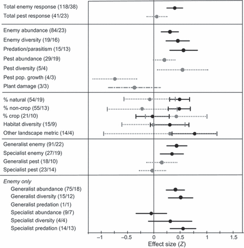

**Figure 1**

Arthropod responses to landscape complexity, based on 46 studies and 159 total responses. Numbers in parentheses denote total number of responses/total number of studies, respectively. Black solid lines represent natural enemy responses; grey dotted lines represent pest responses (dashed line is used for pest response measured at the plant level). Lines demark 95% confidence interval around mean effect size for each group, based on: (a) trophic level (model 1.1 in Table 2), (b) trophic level and arthropod response type (model 1.2), (c) trophic level and landscape metric (model 1.3), (d) trophic level and specialisation (model 1.4), and (e) response type and specialisation for enemies only (model 2.3 based on 38 studies and 118 responses), with ‘predation’ signifying either predation or parasitism. Generalist predation is not shown, as there was only one response in this category. Box-plots are presented in Fig. S1 (Supporting Information) to show the spread and range of effect sizes for each response variable.

### Landscape complexity metrics

All landscape complexity metrics produced a positive response in natural enemies except for inverted % crop and landscape diversity, which were non-significant (Fig. 1c). The differences between the effect size produced by inverted % crop and the effect sizes produced by % natural, % non-crop and the ‘other’ landscape category were statistically significant (*P* = 0.02, 0.03 and 0.02, respectively), but the effect size produced by landscape diversity was not significantly different from that of any of the other landscape metrics. None of the landscape metrics produced a significant response in pests. Including landscape complexity metric as a predictor variable did not improve any model (1.2a compared to 1.2, 1.3 compared to 1.1, or 2.2 compared to 2.1, Table 2).

### Scale

Analysis of those studies that measured multiple scales suggests that specialisation influences the scale at which arthropods respond to landscape complexity (model 3 in Table 2). Generalist responses displayed their strongest correlations with landscape complexity at larger spatial scales than specialists (*F* = 15.85, d.f. = 1, 59, *P* = 0.0002). There was no significant difference in response between pests and enemies on the whole (*F* = 2.64, d.f. = 1, 59, *P* = 0.11), although there was a significant interaction between specialisation and trophic level (*F* = 4.73, d.f. = 1, 56, *P* = 0.03). The responses of generalist pests to landscape complexity tended to be more strongly correlated with larger spatial scales than generalist enemies, while the scale of response for specialist pests and enemies were more similar (Fig. 2).

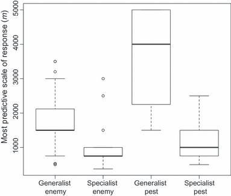

**Figure 2**

Most predictive scale of response to landscape complexity for generalist and specialist pests and enemies, based on 26 studies and 87 responses (model 3 in Table 2). Scale is measured by metres from farm centre. Box-plot shows 25th, 50th (median, dark centre line) and 75th percentiles; whiskers extend to data extremes with hollow points as outliers. Box-plots are used rather than confidence intervals to illustrate that the data are skewed towards scales larger than the median for enemies but not for pests.

Analysis of the subset of studies that not only measured but also reported results at multiple scales further revealed the scale dependence of the effect of landscape complexity, particularly on specialist enemies (model 4 in Table 2). Specialist enemies showed a strong sensitivity to scale, with larger effect sizes in response to landscape complexity at smaller scales (*F* = 6.14, d.f. = 1, 31, *P* = 0.02; Fig. 3a). In contrast, generalist enemies (*F* = 0.83, d.f. = 1, 115, *P* = 0.36; Fig. 3b) and specialist pests (*F* = 1.32, d.f. = 1, 42, *P* = 0.26; Fig. 3c) showed no sensitivity to scale. There were not enough studies of generalist pests at multiple scales to perform an analysis.

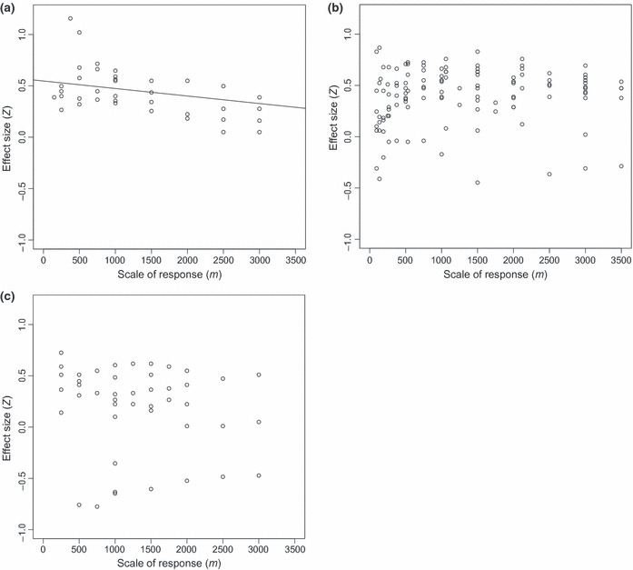

**Figure 3**

## Discussion

The available evidence indicates that landscape complexity in agro ecosystems matters more to natural enemies than to pests, and that the scale at which complexity matters most may be different for specialist than for generalist enemies. Differences in specialist and generalist response have important management implications, and suggest that multi-scale approaches may be required to maintain the full suite of natural enemies important for pest control services. The differences in pest and enemy response found here may not reveal the true relationship between landscape complexity and pest control, however, due to the study methods used; therefore, we propose a shift in approach for this field of research.

### Effects of landscape complexity on enemies vs. pests

Enemies are positively affected by landscape complexity, regardless of which arthropod response type was measured. This result was robust to representational biases among research groups, crop type, geographic location, taxonomic group and different measures of diversity in the data set (Appendix S1). Moreover, while the Spearman-rank correlations suggest a publication bias towards larger effect sizes, the fail-safe number indicates that the overall results would be unlikely to change even with the addition of unpublished studies. We therefore feel confident in our conclusions regarding the positive relationship between natural enemies and landscape complexity, based on the number of studies at hand.

Our analysis does not find strong evidence of these landscape effects on enemies cascading down to pests. Pest abundance and plant damage showed no relationship to landscape complexity. The categories that did show significant responses, pest diversity and pest population growth, had both low sample sizes and opposite responses (positive, *N* = 5 and negative, *N* = 3, respectively). If indeed a true diversity effect occurs, it is unclear whether increased pest diversity is a net positive or negative for pest control. On one hand, a greater diversity of herbivorous insects (particularly if it included a larger number of serious economic pests) would generally be seen by farmers as undesirable. On the other hand, diversity of pests could be considered beneficial, if interspecific competition or apparent competition mediated through shared natural enemies occurs (Langer & Hance 2004). Moreover, a more diverse herbivore community has been shown to enhance the diversity of the enemy community (Dyer & Letourneau 2003; Pearson & Dyer 2006), which increases the potential for facilitative or synergistic effects among natural enemies (Losey & Denno 1998; Cardinale *et al.* 2003; Schmidt *et al.* 2003; Snyder & Ives 2003).

Several confounding factors could result in the lack of a relationship between landscape complexity and pest abundance (for which we have the most data), despite the strong relationship of landscape complexity with natural enemy measures. First, spatial heterogeneity associated with complexity may reduce an enemy’s ability to find its prey, undermining the capacity for top-down control (Pacala *et al.* 1990) that is known to occur in closed (laboratory or greenhouse) conditions (Luck *et al.* 1988). Second, bottom-up factors such as resource concentration within landscapes may be more important in determining pest distributions than top-down factors in some systems (Root 1973). Current methods of measuring landscape complexity often may not capture the distribution of resources for pests. For example, pests may respond not only to crops but also to other plants on the farm (including weeds; e.g. Chaplin-Kramer *et al.* 2011) and in the surrounding landscape (including native plants; e.g. Baumgartner & Warren 2005); these are not captured in the coarse land-cover designations of ‘natural’ or ‘non-crop’ that are often used. Other bottom-up factors that may be associated with increased landscape complexity (e.g. lower soil quality, reduced industrial inputs) could also impact pest abundances indirectly, *via* their effects on yields or plant health, further confounding the relationship between landscape complexity and pests. Pesticides are another important factor influencing pest populations and potentially varying over landscape gradients, but rarely measured in these studies on complexity. Together, the effects of spatial heterogeneity and bottom-up factors may overwhelm the ability of natural enemies to provide adequate control in some agricultural systems.

Yet another explanation for the lack of relationship between landscape complexity and pests is that current methods and metrics do not capture the magnitude of pest control services that are being delivered. The vast majority of studies measuring pest response (over 80% of the pest studies in our analysis) use abundance as a static indicator of ‘pest control’ rather than measuring the impact of natural enemies on pest populations over time. Pest abundance alone may be an inadequate measure of the extent to which pests are impacted by top-down control, since the underlying variation in pest distributions, and thus their abundance in the absence of control, remains unknown (see below, Future research needs).

### Effects of landscape complexity metrics

Authors have used a wide array of measurements to characterise landscapes, reflecting in part the availability of remotely sensed data at the landscape scale (i.e. aerial or satellite imagery) and in part the differences among study and crop systems. These among-study differences may obscure the effect of interest (natural enemy and pest responses to landscapes comprised of a larger proportion of favourable habitats such as natural and semi-natural areas), and therefore future work should attempt to standardise landscape metrics. Standardising the definition across different studies is important for drawing general conclusions that may aid management, but the metrics must be chosen carefully to appropriately characterise the landscape. Per cent crop (inverted in our study) may not be a good metric for landscape complexity; in this study it failed to reveal the positive natural enemy response that many of the other metrics produced. Studies that used % crop as a measure of landscape simplification were predominantly located in the midwestern US, where the land not occupied by crops may sometimes be habitat beneficial to natural enemies, but may also include other land uses, such as residential or industrial development. Landscape diversity was also not a strong predictor of natural enemy response, potentially for similar reasons. A landscape with a mix of urban, industrial, residential and rural land uses may be diverse without providing much habitat to sustain natural enemy populations. Given the lack of natural enemy response to % crop, the strongly positive response to % non-crop is curious, until the setting of these studies is taken into consideration. Studies that used % non-crop as a measure for landscape complexity were mostly European studies, and the non-crop habitats in the landscapes studied there consisted largely of natural or semi-natural habitat within agricultural landscapes. Therefore, while % non-crop performed more similarly to % natural as a metric of landscape complexity in this analysis, its definition is system specific; the percentage of natural habitat surrounding a farm is a more consistent metric and should therefore be preferred.

### Effects of landscape complexity on specialists vs. generalists

Both specialist and generalist enemies (and many pests as well) utilize favourable habitats located around the farm for floral resources or overwintering sites (Landis *et al.* 2000). Generalists may rely more on surrounding regions for alternate prey or host-plants, but off-farm effects on these arthropods could have positive or negative effects on the farm, supplying natural enemies or pests to the farm, or drawing them away from it. Our analysis (model 2.3 in Table 2) indicated a stronger response to landscape complexity for the on-farm abundance of generalist enemies compared to specialist enemies. This result could be an artifact of the chosen scale of study, however, since nearly half of the specialist enemy responses in this meta-analysis come from studies that did not measure multiple scales and therefore may not have measured the most predictive scale (see below, Effects of scale).

The lack of differentiation between specialist and generalist pest response to landscape complexity could also be attributed to a failure to capture the appropriate scale, but may be at least partly due to the chosen definitions of specialists and generalists. The definition of a specialist is much more specific for enemies than for pests; a specialist enemy has only one host species, whereas a pest is often considered a specialist if it is limited to one particular family of host plants. Even very specialised pests may find alternate hosts in off-crop habitat, perhaps with equal frequency as a generalist pest, depending on the prevalence of the host-plant family (e.g. weedy mustard for cabbage aphid; Chaplin-Kramer *et al.* 2011). Therefore, while the specialist/generalist distinction may provide useful insights into understanding enemy distributions, these categories may be less useful for pests.

### Effects of scale

We found no significant difference in the most predictive scale associated with enemy vs. pest response to landscape complexity, contradicting previous studies that have shown enemies to be best predicted at smaller scales than pests (Thies *et al.* 2005; Perovic *et al.* 2010). However, our analysis was conducted across pooled groups of enemies and pests, and therefore loses information about the relationship between specific predator-prey pairs. Seven studies included in our analysis measured both enemy and pest response simultaneously at multiple scales, allowing for a direct comparison of the most predictive scales of response of enemies and their prey. Five of those seven showed enemy and pest response best predicted by the same scale, suggesting that our result may indeed describe a broader trend, despite the pooled analysis.

Generalist enemies responded positively to landscape complexity at all scales of study, but the most predictive scale for generalists was larger than for specialists. For specialist enemies, the effect of landscape complexity was strongest at the smallest scales, when the off-farm habitat was closer to the farm. The effect size of specialist enemy response at the smallest scales (Fig. 3a) was similar to the mean effect size of generalist enemy response across all scales (Fig. 3b), suggesting that specialists and generalists might be equally dependent on off-farm habitat, but that generalists may simply be able to utilize it across a broader range than specialists.

The differences between the scale of response in specialist and generalist enemies raise important management implications. If generalists provide the bulk of the pest control in a system, a successful pest control programme may need to promote landscape-scale or cooperative approaches to boost generalist enemy populations, since the most predictive scale of response was larger for generalists than for specialists. If specialists are the main enemies, local management by individual growers may be more effective, since specialists appear to be most benefitted by landscape complexity close to the crop site. Identifying the dominant natural enemies in specific systems or for specific pests is an important factor in understanding how to manage landscapes for the provision of natural pest control, if more abundant natural enemies provide better control (Tscharntke *et al.* 2007). Characterising the dominant natural enemies according to their degree of specialisation and their scales of response will allow general rules such as those established herein to provide instructive management advice.

### Future research needs

Most studies in our analysis measured natural enemy responses to landscape complexity; fewer assessed pest responses to landscape complexity, and very few studies measured either natural enemy reduction of pest populations or changes in crop yield with respect to landscape complexity (Table 1). Yet, it is these latter variables that need to be measured to assess pest control services, suggesting that a fundamental redirection is needed in this relatively new and emerging field of research.

More specifically, measuring pest control in terms of pest abundances in the short term may severely underestimate the contribution made by natural enemies in constraining pest populations. Other factors, such as temperature, precipitation, wind patterns and alternate host plant presence, also influence pest abundances across landscape gradients, potentially masking the effects of natural enemies. Therefore, research on pests should consider not only spatial comparisons across gradients, but also more importantly, how pest populations change over time and whether or not population sizes are lower with the action of natural enemies than they would be without. Experiments measuring natural enemy suppression of pest population growth and/or plant damage, coupled with models of population dynamics, would provide better indicators of comparative pest control than abundance measurements alone.

One method to isolate the impact of landscape-mediated natural enemy increases on pest populations is via *in situ* cage studies, measuring pest population growth in the presence and absence of resident natural enemies (e.g. Gardiner *et al.* 2009a). Not only does this measure predation, but it also accounts for pest reproduction rates, which may vary widely over landscape gradients in response to temperature and other environmental factors. Thus, cage studies enhance our understanding of the degree to which natural enemies affect pest population growth. The few studies that have utilised cages in this manner (shown in Fig. 1b and Table 1 as ‘pest pop. growth’) have demonstrated a reduction in pest population growth correlated with greater abundance and/or diversity of natural enemies in complex landscapes. However, more study is needed before broader conclusions can be drawn; the only pest taxon examined using these methods to date is aphids. More mobile pests may be difficult to study with enemy-exclosure cages if the cages also prevent natural levels of pest emigration, resulting in artificially high pest populations. Nonetheless, other groups like lepidopterans with less mobile larval stages should be included in future research in this area.

A second, more inferential, method for measuring the impact of natural enemies on pest populations is to track both pest and enemy densities over time to determine whether or not pest populations show evidence of constraint, by change in the trajectory of their growth. This method is correlative (pest population changes may coincide with but are not necessarily driven by changes in natural enemies) but is complementary to the cage studies, since it better captures the reality of field conditions. However, only half of the pest abundance studies in our analysis sampled their sites more than once; the remainder limited their sampling to one point in time. This ‘snapshot’ sampling misses the opportunity to examine pest population trajectories, and thus the possibility of detecting a change in trajectory that may provide some evidence of pest control. The bulk of the studies that did sample more frequently did not analyse their data to consider changes in population growth, but rather pooled the sampled periods to acquire an average or cumulative measure (Jonsen & Fahrig 1997; Holland & Fahrig 2000; den Belder *et al.* 2002; Ramos 2008; Ekroos *et al.* 2010; Noma *et al.* 2010). In these cases it appears that the necessary data have been obtained, but the analysis has simply not been conducted in a way that allows an exploration of population dynamics.

Finally, the most fundamental measure for the ecosystem service of pest control is the prevention or reduction of crop damage, and wherever possible this measure should be included in studies investigating pest response to landscape complexity (e.g. Thies & Tscharntke 1999). Again, very few studies have measured crop damage across landscape gradients (Fig. 1b; Table 1), and for only one system (the rape-pollen beetle in oilseed rape). Expanding this area of research should be a priority for the study of pest control services. Much like the argument for measuring pest population growth in addition to abundance, it is important to measure not only crop damage but also *avoided* crop damage. The measure of the ecosystem service of pest control is whether or not resident natural enemies are preventing some amount of crop damage that would otherwise occur. Cage studies could again be a useful tool for measuring avoided crop damage along a landscape gradient.

In general, longer term (i.e. decadal) data are needed to parse out anomalous years that may skew results of studies conducted over just 1 or 2 years. With such long-term data, pest control could be assessed as the frequency of exceeding certain thresholds of pest abundance or damage, rather than a single time point, providing a more robust understanding of pest population dynamics and the stability of pest control services. Such data are completely lacking from the literature, however. Creative use of proxies from other data sources (e.g. government records of insurance claims) may be necessary to achieve sufficiently long time scales for investigating the effects of landscape complexity on pest control stability. Future studies should aim to measure pest control using a variety of these techniques to better characterise this important ecosystem service and its relationship to landscape complexity or land management.

## Acknowledgements

The authors wish to thank Perry De Valpine and Laura Prugh for their invaluable assistance in the analytical process, and Alex Harmon-Threatt, Shalene Jha and Justin Kitzes for their insightful comments on the manuscript. Carsten Thies and Felix Bianchi provided additional data. The Land Institute provided funding for RCK, EB and MO, and facilitated this collaboration. The Robert van den Bosch Scholarship in Biological Control provided funding for RCK.

RCK and EB gathered data, MO constructed the database and conducted preliminary analyses, CK set an overall framework for the questions. RCK conducted the final analysis and wrote the first draft of the manuscript, and all authors contributed substantially to the revisions.

## Citing Literature

September 2011

Pages 922-932

### Recommended

[figure not shown]